# Final Project

Data Science for Biologists, Spring 2021

Sam Dorofy

**Dogs can’t operate MRI scans… but catscan!**

Why choose this data set?

My current job at the American College of Radiology requires me to look at brains scans all day and I think it’s truly fascinating! I thought it would be neat to merge my two worlds of school and work together for a final project.

## Introduction

```r
brain_tumors <- read_csv("dorofy_braintumor.csv")
glimpse(brain_tumors)
```

```
## Rows: 1,644
## Columns: 19
## $ Image                <chr> "Image1", "Image2", "Image3", "Image4", "Image5"…
## $ Mean                 <dbl> 23.4485168, 4.3983307, 3.2442627, 8.5113525, 21.…
## $ Variance             <dbl> 2538.98563, 834.85303, 642.05917, 1126.21419, 22…
## $ `Standard Deviation` <dbl> 50.388348, 28.893823, 25.338886, 33.559115, 47.2…
## $ Entropy              <dbl> 0.6511741, 0.9535317, 0.9660645, 0.8687651, 0.68…
## $ Skewness             <dbl> 1.984202, 6.495203, 7.772860, 3.763142, 1.936029…
## $ Kurtosis             <dbl> 5.421042, 43.349355, 61.756034, 15.107579, 4.722…
## $ Contrast             <dbl> 181.46771, 76.74589, 81.75241, 362.29121, 312.43…
## $ Energy               <dbl> 0.7815569, 0.9727695, 0.9801609, 0.9217862, 0.80…
## $ ASM                  <dbl> 0.6108312, 0.9462805, 0.9607154, 0.8496899, 0.64…
## $ Homogeneity          <dbl> 0.8470333, 0.9807616, 0.9850659, 0.9492953, 0.88…
## $ Dissimilarity        <dbl> 2.76541144, 0.54860530, 0.54041144, 2.76572524, …
## $ Correlation          <dbl> 0.9685761, 0.9597505, 0.9442587, 0.8590271, 0.93…
## $ Coarseness           <dbl> 7.458341e-155, 7.458341e-155, 7.458341e-155, 7.4…
## $ PSNR                 <dbl> 97.97463, 110.34660, 112.26630, 101.95579, 97.63…
## $ SSIM                 <dbl> 0.7770111, 0.9779528, 0.9853620, 0.8810152, 0.76…
## $ MSE                  <dbl> 0.171163194, 0.009913194, 0.006371528, 0.0684375…
## $ DC                   <dbl> 0.30398870, 0.83901889, 0.84977487, 0.00000000, …
## $ Target               <dbl> 1, 1, 1, 0, 0, 0, 0, 1, 1, 1, 1, 1, 1, 1, 1, 0, …
```

## Question 1

Entropy in MRI scans is used to determine the size and location of a possible brain tumor while Homogeneity refers to the balance of the magnetic field with or without a patient present.

**What is the relationship between the Entropy and Homogeneity values in the brain tumor MRI scans?**

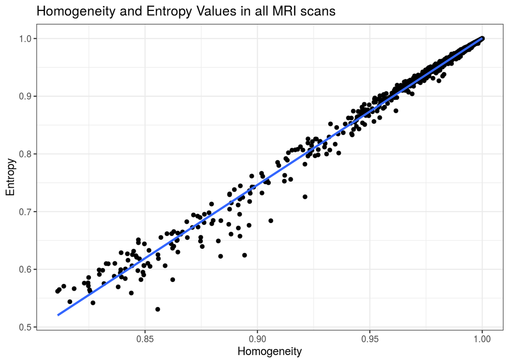

```r
brain_tumors %>% #using the data set
ggplot(aes(x = Homogeneity, y = Entropy)) +
  #want Homogeneity on x axis and Entropy on y axis
geom_point() + #plotting a scatterplot
geom_smooth(method = 'lm') + #want a trendline
labs(x = "Homogeneity", #title of x axis
     y = "Entropy", #title of y axis
     title = "Homogeneity and Entropy Values in all MRI scans") +
  #plot title
  theme_bw() #plot theme
```

**Explanation**

There is a linear relationship between Entropy and Homogeneity. When Entropy increases, so does Homogeneity and vice versa. This is vital to know because if these values did not relate to each other like this, this could mean the MRI calibration is off or that the scan was performed wrong.

## Question 2

**Of all of the patients in the study, how many have a brain tumor or no tumor?**

[figure not shown]

```r
tumor_presence <- ifelse(brain_tumors$Target==0, "yes","no")
#'0' is no tumor and '1' is a tumor

brain_tumors %>% #using the dataset
  ggplot(aes(x = tumor_presence, #using new variable on x axis
            #plot amount of images on y axis
             fill = tumor_presence)) + #fill according to 'yes' and 'no'
  geom_bar() + #want bar graph
  scale_fill_manual(values=c("darkmagenta","pink"), "Tumor Present") +
  #change colors of the bars according to 'yes' and 'no' tumor presence
  labs(x = "Presence of Brain Tumor", #title of x axis
       y = "Number of Patients", #title of y axis
       title = "How Many Patients Have a Brain Tumors Present?") +
  #title of plot
  theme_grey() #plot theme
```

## Question 3

**Are there a lot of patient images with a mean above 10? Does a higher mean most likely result in a high entropy? Lastly, can you base whether a patient has a brain tumor or not going off of mean and entropy results?**

```r
brain_tumors %>% #using the data set
  filter(Mean>=10) -> top_mean #only want mean values > 10

top_mean %>% #using new data set
count(Mean) #count all mean > 10
```

```
## # A tibble: 149 x 2
##     Mean     n
##  * <dbl> <int>
##  1  10.0     1
##  2  10.0     1
##  3  10.1     1
##  4  10.1     1
##  5  10.3     1
##  6  10.3     1
##  7  10.3     1
##  8  10.5     1
##  9  10.5     1
## 10  10.8     1
## # … with 139 more rows
```

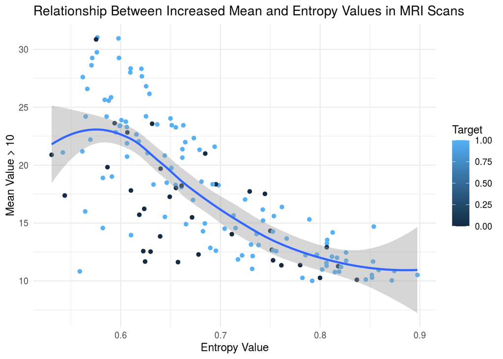

```r
top_mean %>% #using new data set filtering mean > 10
  ggplot(aes(x = Entropy, y = Mean, fill = Target)) +
  #labeling x and y axes and filling according to brain tumor presence
  geom_point(aes(color = Target)) + #color according to brain tumor presence
    geom_smooth() + #want a trendline
  labs(x = "Entropy Value", #x axis title
       y = "Mean Value > 10", #y axis title
       title = "Relationship Between Increased Mean and Entropy Values in MRI Scans") +
  #plot title
  theme_minimal() #plot theme
```

**Explanation**

No, there are not a lot of images with a mean higher than 10. This was interesting to me in that almost the same number of patients had a brain tumor present.

## Question 4

**Skewness and Kurtosis values in MRI scans can be useful in differentiating between benign and malignant tumors. What is the relationship between the Skewness and Kurtosis values in this data set?**

```r
brain_tumorsna <- brain_tumors %>% drop_na()
#need to drop n/a's otherwise graph isn't pretty
brain_tumorsna
```

```
## # A tibble: 1,275 x 19
##    Image   Mean Variance `Standard Devia… Entropy Skewness Kurtosis Contrast
##    <chr>  <dbl>    <dbl>            <dbl>   <dbl>    <dbl>    <dbl>    <dbl>
##  1 Imag… 23.4     2539.             50.4    0.651     1.98     5.42    181.
##  2 Imag…  4.40     835.             28.9    0.954     6.50    43.3      76.7
##  3 Imag…  3.24     642.             25.3    0.966     7.77    61.8      81.8
##  4 Imag…  8.51    1126.             33.6    0.869     3.76    15.1     362.
##  5 Imag… 21.0     2235.             47.3    0.685     1.94     4.72    312.
##  6 Imag… 11.4      999.             31.6    0.761     2.53     7.39    304.
##  7 Imag…  0.405     68.4             8.27   0.995    20.4    417.       17.8
##  8 Imag…  5.96     937.             30.6    0.927     5.02    26.2      57.2
##  9 Imag…  6.18     895.             29.9    0.917     4.71    23.2      73.7
## 10 Imag…  0.261     52.3             7.23   0.997    27.7    769.       18.0
## # … with 1,265 more rows, and 11 more variables: Energy <dbl>, ASM <dbl>,
## #   Homogeneity <dbl>, Dissimilarity <dbl>, Correlation <dbl>,
## #   Coarseness <dbl>, PSNR <dbl>, SSIM <dbl>, MSE <dbl>, DC <dbl>, Target <dbl>
```

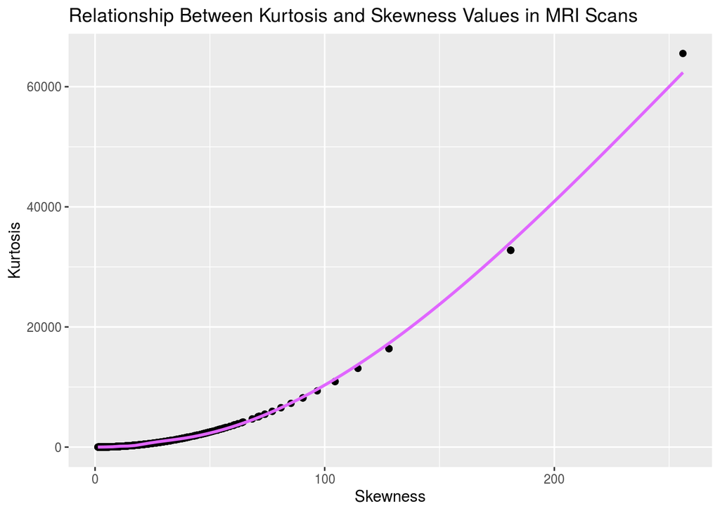

```r
brain_tumorsna %>% #using new data set
 ggplot(aes(x = Skewness, #skewness on x axis
           y = Kurtosis)) + #kurtosis on y axis
    geom_point(size = 1.75) + #change size of points on scatterplot
  geom_smooth(color = "mediumorchid1") + #color the trendline
  labs(x = "Skewness", #x axis title,
       y = "Kurtosis", #y axis title,
       title = "Relationship Between Kurtosis and Skewness Values in MRI Scans") +
  #plot title
  theme_grey() #plot theme
```

**Explanation**

The relationship between Skewness and Kurtosis looks to be somewhat exponential. As Skewness values increase, the Kurtosis values do as well but almost 200x as much.